# Tutorial: Entendimiento de los datos con PySpark

## Introducción

```
¿Qué aprenderá?
En este tutorial aprenderá cómo puede realizar el entendimiento de los datos en el contexto de un proyecto de analítica. A nivel de la metodología ASUM-DM estamos en la fase de entendimiento de datos y en la arquitectura nos encontramos trabajando con el componente de fuentes de datos.

¿Qué construirá?
En este tutorial realizará la exploración o perfilamiento de un conjunto de datos provenientes de una base de datos relacional, al igual que un análisis de la calidad de los datos utilizando los DataFrames de PySpark. Además, generará las conclusiones requeridas para ser compartidas en reuniones y formalizadas en la documentación del proyecto. Las conclusiones son variadas pero en general podemos decir que siempre deberían incluir una lista de preguntas o aclaraciones para la organización, conclusiones de los datos/problemas de calidad y alternativas para la limpieza. Un entendimiento de datos sin conclusiones no es útil y tampoco es entendible para personas de negocio.

¿Para qué?
Antes de realizar cualquier tipo de proyecto de datos es necesario entender los datos con unas tareas de exploración o perfilamiento de datos y de análisis de calidad. Esta fase de la metodología permite determinar si es posible o no realizar el proyecto dada la cantidad y calidad de los datos, el tiempo requerido para su preparación y las diferentes actividades que se requieren para mejorar los datos en caso de requerirse.

¿Qué necesita?
Los siguientes requisitos se encuentran instalados en la máquina virtual asignada a cada estudiante, específicamente en el ambiente de anaconda llamado "Tutoriales". Recuerde que tiene a su disposición el tutorial de conexión a máquinas virtuales en la semana 1 de Coursera
1. Python 3 con pip instalado
2. Jupyter Labs
3. Paquetes: Pyspark (3.2.1), pandas (1.2.1), numpy (1.20.0) y matplotlib (3.3.4)
Otros:
1. Controlador Connector J(ya se encuentra configurado)
2. Acceso a servidor remoto MySQL con base de datos relacional "WWImportersTransactional". Recuerde que tiene a su disposición el tutorial de conexión remoto a Mysql en la semana 1 de Coursera
```

Continuando con el proyecto de consultoria de Wide World Importers, el primer paso para iniciar la comprensión de los datos es explorar y entender las fuentes de datos disponibles. Note que esto también nos ayuda a comprender mejor la organización.

## Configuración e importe de paquetes

Se utilizará el paquete de pandas profiling para apoyar el análisis estadístico, y se importan los paquetes de python necesarios

```python
from pyspark.sql import SparkSession
from pyspark.sql import functions
from pyspark.sql.types import StructType
from pyspark import SparkContext, SparkConf, SQLContext
from pyspark.sql.types import FloatType, StringType, IntegerType, DateType
from pyspark.sql.functions import udf, col, length, isnan, when, count
import pyspark.sql.functions as f
import os
from datetime import datetime
from pyspark.sql import types as t
from pandas_profiling import ProfileReport
import matplotlib.pyplot as plt
import numpy as np
```

Configuración del controlador e inicio de sesion Spark

```python
path_jar_driver = "/workspaces/ETL/drivers/mysql-connector-j.jar"
```

```python
#Configuración de la sesión
conf = SparkConf() \
    .set("spark.driver.extraClassPath", path_jar_driver) \
    .set("spark.jars", path_jar_driver)

spark_context = SparkContext(conf=conf)
sql_context = SQLContext(spark_context)
spark = sql_context.sparkSession
```

```
Picked up JAVA_TOOL_OPTIONS: -Xss512k -XX:+UseContainerSupport
Picked up JAVA_TOOL_OPTIONS: -Xss512k -XX:+UseContainerSupport
26/06/16 22:16:07 WARN Utils: Your hostname, codespaces-860f81 resolves to a loopback address: 127.0.0.1; using 10.0.10.233 instead (on interface eth0)
26/06/16 22:16:07 WARN Utils: Set SPARK_LOCAL_IP if you need to bind to another address
26/06/16 22:16:08 WARN NativeCodeLoader: Unable to load native-hadoop library for your platform... using builtin-java classes where applicable
Setting default log level to "WARN".
To adjust logging level use sc.setLogLevel(newLevel). For SparkR, use setLogLevel(newLevel).
```

```python
# Si quiere practicar la conexion con el servidor de base de datos:
db_connection_string = 'jdbc:mysql://157.253.236.120:8080/WWImportersTransactional'
# El usuario es su estudiante _i asignado y su contraseña la encontrará en el archivo excel de Coursera
db_user = 'DB_202613_dp_rojasr1'
db_psswd = '202116178'

PATH='./'
```

## Perfilamiento de los datos

El perfilamiento se basa en varios aspectos: **entendimiento general** de los datos compartidos, validación de **reglas de negocio**, **análisis descriptivo** utilizando estadística descriptiva y diagramas para la visualización de los datos y **análisis de calidad**. El primero hace referencia a tener una comprensiòn global antes de entrar en los detalles, la segunda sobre las reglas, corresponden a especificaciones dadas por el negocio en relación con los datos, un ejemplo de regla de negocio dada es: "Todo producto de la canasta familiar debe tener un precio de IVA equivalente a 19%", dada esta regla de negocio, se debe revisar en los datos suministrados que no hayan valores de IVA menores a 19%. En el tercer aspecto, relacionado con el análisis descriptivo, se revisan estadísticas: mínimo, máximo, media, mediana, distribuciones de los datos, valores nulos, cardinalidad con el fin de comprender en mayor nivel de profundidad los datos compartidos.

### Información dada por la organización relacionada con los datos

El grupo de consultores de analitica descriptiva de Wide World Importers asegura que las tablas Grupo de compras, Ciudades, Colores, Paises, Clientes, Categorias de clientes, Paquetes, Estados y provincias, Productos y Personas ya fueron perfiladas y corregidos; sin embargo le recomiendan revisar el diccionario suministrado dado que todas las tablas serán utilizadas en futuros requerimientos (tutoriales y ejercicios) que lo encuentra aqui. Si tienen alguna duda relacionada con estas tablas deben incluirla en las preguntas o aclaraciones que le entreguen a la organización como parte del resultado de esta fase de entendimiento.

En este punto de la consultorìa, nuestra responsabilidad es analizar las tablas ordenes y detalles de ordenes, relacionadas con al proceso de ordenes de compra de productos. Con respecto a esas fuentes nos comentan lo siguiente:

- La tasa de impuesto es de 10% o 15%
- Son 74.179 órdenes detalladas en 57.981 lineas de detalle de órdenes realizadas desde 2013
- El formato de fechas manejado es YYYY-MM-DD HH:MM:SS si tienen hora, minutos y segundos. De lo contrario el formato es YYYY-MM-DD

### Conexión a fuente de datos y acceso a los datos

#### Conexión a fuente de datos

A continuación encuentra las funciones para conectarse a la fuente de datos (archivo csv o base de datos) y retornar un dataframe que es el que se utilizará posteriormente para manipular los datos.

```python
def obtener_dataframe_de_bd(db_connection_string, sql, db_user, db_psswd):
    df_bd = spark.read.format('jdbc')\
        .option('url', db_connection_string) \
        .option('dbtable', sql) \
        .option('user', db_user) \
        .option('password', db_psswd) \
        .option('driver', 'com.mysql.cj.jdbc.Driver') \
        .load()
    return df_bd
```

```python
print("db_user:", db_user)
print("db_psswd vacío?:", db_psswd == "" or db_psswd is None)
```

```
db_user: DB_202613_dp_rojasr1
db_psswd vacío?: False
```

#### Cargue de datos

Para consultar desde la base de datos se puede acceder directamente a la tabla dado su nombre o se puede especificar la sentencia SQL de un "SELECT" completo para traer la información total o parcial de la tabla que se requiere. A continuación un ejemplo de cada uno de estos usos. Acceso directo para el caso de órdenes y acceso con sentencia SQL para el caso de detallesOrdenes.

```python
sql_ordenes = 'WWImportersTransactional.OrdenesCopia'
```

```python
sql_detallesOrdenes = '''(SELECT
        Detalle_orden_ID,
        ID_de_pedido,
        ID_Producto,
        Descripcion,
        ID_Tipo_Paquete,
        Cantidad,
        Precio_unitario,
        Tasa_de_impuesto,
        Cantidad_seleccionada,
        Seleccion_completada_cuando
        FROM WWImportersTransactional.DetallesOrdenesCopia) AS Compatible'''
```

```python
print(db_connection_string)
```

```
jdbc:mysql://157.253.236.120:8080/WWImportersTransactional
```

```python
#Se cargan los dataframes desde la base de datos
ordenes = obtener_dataframe_de_bd(db_connection_string, sql_ordenes, db_user, db_psswd)
detallesOrdenes = obtener_dataframe_de_bd(db_connection_string, sql_detallesOrdenes, db_user, db_psswd)
```

### Entendimiento general de datos

Para ver una muestra de los datos, utilice el comando *show* ingresando el número de filas que quiere ver

```python
ordenes.show(5)
```

```
+------------+-------------+--------------+------------------------------+-------------------------+----------------------+---------------+-------------------------+--------------------------------------+-------------------------------------------+-----------+------------------------+---------------…
|ID_de_pedido|ID_de_cliente|ID_de_vendedor|Seleccionado_por_ID_de_persona|ID_de_persona_de_contacto|ID_de_pedido_pendiente|Fecha_de_pedido|Fecha_de_entrega_esperada|Numero_de_pedido_de_compra_del_cliente|Pedido_pendiente_de_suministro_insuficiente|Comentarios|Instrucciones_de_entrega|Comentarios_int…
+------------+-------------+--------------+------------------------------+-------------------------+----------------------+---------------+-------------------------+--------------------------------------+-------------------------------------------+-----------+------------------------+---------------…
|       44495|          139|             6|                            18|                     1277|                  NULL|    Mar 05,2015|               2015-03-06|                                 13118|                                       true|       NULL|                    NULL|               …
|       45625|          892|            15|                            17|                     3092|                  NULL|    Mar 24,2015|               2015-03-25|                                 11303|                                       true|       NULL|                    NULL|               …
|       23645|          542|             8|                             9|                     2283|                  NULL|    Mar 18,2014|               2014-03-19|                                 18340|                                       true|       NULL|                    NULL|               …
|       47505|          924|            15|                             4|                     3124|                  NULL|    Apr 21,2015|               2015-04-22|                                 18645|                                       true|       NULL|                    NULL|               …
|       37755|           43|             7|                            10|                     1085|                  NULL|    Nov 11,2014|               2014-11-12|                                 16259|                                       true|       NULL|                    NULL|               …
+------------+-------------+--------------+------------------------------+-------------------------+----------------------+---------------+-------------------------+--------------------------------------+-------------------------------------------+-----------+------------------------+---------------…
only showing top 5 rows
```

```python
detallesOrdenes.show(5)
```

```
[Stage 1:>                                                          (0 + 1) / 1]
```

```
+----------------+------------+-----------+--------------------+---------------+--------+---------------+----------------+---------------------+---------------------------+
|Detalle_orden_ID|ID_de_pedido|ID_Producto|         Descripcion|ID_Tipo_Paquete|Cantidad|Precio_unitario|Tasa_de_impuesto|Cantidad_seleccionada|Seleccion_completada_cuando|
+----------------+------------+-----------+--------------------+---------------+--------+---------------+----------------+---------------------+---------------------------+
|          206857|       65697|        205|Tape dispenser (B...|              7|      60|             32|              15|                   60|        2016-01-27 11:00:00|
|          206858|       65698|         45|Developer joke mu...|              7|       3|             13|              15|                    3|        2016-01-27 11:00:00|
|          206859|       65698|         72|Ride on toy sedan...|              7|       3|            230|              15|                    3|        2016-01-27 11:00:00|
|          206861|       65698|        115|Superhero action ...|              7|       1|             34|              15|                    1|        2016-01-27 11:00:00|
|          206862|       65698|         10|                   a|              7|       5|             32|              15|                    5|        2016-01-27 11:00:00|
+----------------+------------+-----------+--------------------+---------------+--------+---------------+----------------+---------------------+---------------------------+
only showing top 5 rows
```

Como puede observar en la tabla de ordenes tenemos información **relacionada con el cliente, el empleado y con la órden**. La información del cliente es su identificador *ID_de_cliente*, el identificador de la persona que eligió la órden *eleccionado_por_ID_de_persona*, el identificador de la persona de contacto *ID_de_persona_de_contacto*, el *Número_de_pedido_de_compra_del_cliente*. La información del empleado es su identificador *ID_de_vendedor*. La información de la órden es: el identificador de la órden *ID_de_pedido*, el identificador que indica si es un pedido pendiente *ID_de_pedido_pendiente*, la fecha en la que se realizó el pedido *Fecha_de_pedido*, la fecha de entrega esperada del pedido *Fecha_de_entrega_esperada* y *Pedido_pendiente_de_suministro_insuficiente* que indica si es un pedido pendiente o no. El esquema de un DataFrame incluye los nombres de las columnas asi como el tipo de dato. Recuerde que tipo de dato (e.g., booleano, caracteres, enteros, flotantes, colecciones) es diferente a tipo de variable (numérica y categórica).

```python
ordenes.schema
```

```
StructType([StructField('ID_de_pedido', IntegerType(), True), StructField('ID_de_cliente', IntegerType(), True), StructField('ID_de_vendedor', IntegerType(), True), StructField('Seleccionado_por_ID_de_persona', IntegerType(), True), StructField('ID_de_persona_de_contacto', IntegerType(), True), Stru…
```

Por otra parte, en los detalles de ordenes se tiene **información del pedido y del producto**. Del pedido se tiene el identificador del detalle *Detalle_orden_ID*, el identificador de la orden a la que está relacionado cada detalle *ID_de_pedido*, la *Cantidad_seleccionada* del producto para la orden, la fecha de selección *Seleccion_completada_cuando*. Del producto tenemos el *ID_Producto*, su *Descripcion*, el tipo de paquete *ID_Tipo_Paquete* (Ej. 1.Bolsa, 4. Caja), la *Cantidad*, el *Precio_unitario*, y la *Tasa_impuesto* asociada a ese producto. Una primera aclaración a solicitar por parte del negocio es cuál es la diferencia entre cantidad y cantidad seleccionada

```python
detallesOrdenes.schema
```

```
StructType([StructField('Detalle_orden_ID', IntegerType(), True), StructField('ID_de_pedido', IntegerType(), True), StructField('ID_Producto', IntegerType(), True), StructField('Descripcion', StringType(), True), StructField('ID_Tipo_Paquete', IntegerType(), True), StructField('Cantidad', IntegerTyp…
```

**¿Qué es una fila de cada fuente compartida?** Con estos análisis podemos concluir que una fila de órdenes representa la órden realizada por un cliente y atendida por un empleado. Mientras que el detalle de órden coincide con su nombre y contiene el detalle de cada producto solicitado en una órden.

Una vez entendida en términos generales la estructura de los datos, es necesario conocer la cantidad de datos disponibles, esto se hace con count() y con columns, que retornan el número de filas y número de columnas respectivamente.

```python
print((detallesOrdenes.count(), len(detallesOrdenes.columns)),(ordenes.count(), len(ordenes.columns)))
```

```
[Stage 5:>                                                          (0 + 1) / 1]
```

```
(58320, 10) (88258, 14)
```

### Revisión de reglas de negocio

Primero se confirman las reglas proporcionadas por el negocio, la primera que asegura que la tasa de impuesto es de 10% o 15% vemos que no es correcta pues al seleccionar esa columna e indicar que queremos ver los valores distintos que puede tomar se observa únicamente el valor 15

```python
detallesOrdenes.select("Tasa_de_impuesto").distinct().show()
```

```
[Stage 8:>                                                          (0 + 1) / 1]
```

```
+----------------+
|Tasa_de_impuesto|
+----------------+
|              15|
+----------------+
```

Si se quiere saber cuántos registros hay por cada valor posible, existen varias formas de hacerlo, en la siguiente celda se muestra cómo iterar sobre los valores resultado de una consulta y cómo filtrar el número de registros para cada valor usando filter y select where, también se da un ejemplo de uso de group by y agregaciones

Pyspark tiene funcionalidades de los DataFrames que permiten explorar los datos por medio de agregaciones y estas funcionan similar a como se usan en SQL

Primero, se debe agrupar sobre una columna con el método *groupBy* y después se pueden realizar agregaciones sobre otras columnas con el método *agg*. La sintaxis es la siguiente:

```
   DataFrame.groupBy('COLUMN NAME').agg({'COLUMN NAME 1': 'mean', 'COLUMN NAME 2': 'count', 'COLUMN NAME 3': 'max'})
```

En cualquiera de los 3 casos se observa que el resultado es el mismo

```python
for row in detallesOrdenes.select('Tasa_de_impuesto').distinct().collect():
    texto = 'número de registros con '+str(row.Tasa_de_impuesto)+ '% de tasa de impuesto: '
    opc1 ="--Usando filter--"
    print(texto+opc1+str(detallesOrdenes.filter(col('Tasa_de_impuesto')==row.Tasa_de_impuesto).count()))

    opc2 ="--Usando Select where--"
    print(texto+opc2+str(detallesOrdenes.select().where(col('Tasa_de_impuesto')==row.Tasa_de_impuesto).count()))
    opc3 ="--Usando group by--"
detallesOrdenes.groupBy("Tasa_de_impuesto").count().show()
```

```
número de registros con 15% de tasa de impuesto: --Usando filter--58320
```

```
número de registros con 15% de tasa de impuesto: --Usando Select where--58320
```

```
[Stage 20:>                                                         (0 + 1) / 1]
```

```
+----------------+-----+
|Tasa_de_impuesto|count|
+----------------+-----+
|              15|58320|
+----------------+-----+
```

La conclusión es entonces que la regla no es completamente cierta, pues en los datos no hay ningun registro con tasa_de_impuesto de 10%, es necesario pedir aclaraciones al negocio en relación a este descubrimiento. La segunda regla de negocio implica conocer el número de registros y de variables que los describen, es decir, el número de filas y columnas del DataFrame respectivamente, esto se logra usando count() y columns

```python
print((detallesOrdenes.count(), len(detallesOrdenes.columns)),(ordenes.count(), len(ordenes.columns)))
```

```
[Stage 26:>                                                         (0 + 1) / 1]
```

```
(58320, 10) (88258, 14)
```

Podemos concluir que esta regla de negocio no es cierta dado que el número de registros no parece coincidir con el número dado por el negocio, una primera intuición nos dice que podrían haber registros duplicados y si existen hay que reportarlos y eliminarlos en la fase de preparación de los datos. Esta es la primera conclusión del análisis de entendimiento de datos.

```python
detallesOrdenes.distinct().count(), ordenes.distinct().count()
```

```
(58239, 74179)
```

Como pueden ver hay 58.239 detalles de orden y 74.179 ordenes únicas. Es decir que sabemos que hay 14.079 ordenes completamente repetidas, pero entonces ¿por qué el número de detalles de orden que hay en los datos no coincide con el dado por la organización?

La respuesta es que no basta solo con revisar si hay registros idénticos, puede que hayan registros con columnas identificadoras o lo que conoceriamos como las llaves primarias repetidas pero con diferentes valores en los otros atributos. Esto se da principalmente cuando las bases de datos están mal construidas, aunque hay casos en los cuales tiene sentido. En cualquier caso es nuestra responsabilidad preveer estos escenarios, por ende se revisan los datos por la llave primaria de esta tabla:

```python
detallesOrdenes.select(col('Detalle_orden_ID')).distinct().count()
```

```
57981
```

De esta manera vemos que hay una diferencia de 258 registros cuyo identificador es el mismo y vemos que el número de identificadores únicos coincide con el número dado por el negocio, la segunda conclusión es entonces que tenemos 258 registros que representan el mismo detalle de orden pero con valores distintos.

Lo siguiente es verificar las fechas en los datos, nos dicen que son ordenes desde 2013 por lo que se revisa la fecha mínima del atributo Fecha_de_pedido, como se observa la fecha mínima es de 2014 enero 1, esto nos indica que la regla de negocio no es correcta o faltan datos, esta es la tercera conclusión

```python
ordenes.agg({"Fecha_de_pedido": "min"}).show()
```

```
[Stage 47:>                                                         (0 + 1) / 1]
```

```
+--------------------+
|min(Fecha_de_pedido)|
+--------------------+
|          2014-01-01|
+--------------------+
```

```
Como ve en el comando anterior las agregaciones también se pueden realizar sin un groupBy.
```

```python
regex = "[0-2]\d{3}-(0[1-9]|1[0-2])-(0[1-9]|[1-2][0-9]|3[0-1])"
cumplenFormato = ordenes.filter(ordenes["Fecha_de_pedido"].rlike(regex))
print("Número total de ordenes: "+str(ordenes.count())+", número de ordenes con formato correcto: "+str(cumplenFormato.count()))
```

```
[Stage 53:>                                                         (0 + 1) / 1]
```

```
Número total de ordenes: 88258, número de ordenes con formato correcto: 68223
```

Para ver los registros que no cumplen con el formato podemos negar la condición del filtro con el símbolo ~ al principio:

```python
noCumplenFormato = ordenes.filter(~ordenes["Fecha_de_pedido"].rlike(regex))
noCumplenFormato.count(), noCumplenFormato.select(col("Fecha_de_pedido")).show()
```

```
[Stage 59:>                                                         (0 + 1) / 1]
```

```
+---------------+
|Fecha_de_pedido|
+---------------+
|    Mar 05,2015|
|    Mar 24,2015|
|    Mar 18,2014|
|    Apr 21,2015|
|    Nov 11,2014|
|    Oct 16,2014|
|    May 04,2015|
|    Nov 24,2014|
|    May 07,2015|
|    Sep 10,2014|
|    Nov 03,2015|
|    Dec 19,2014|
|    Apr 27,2016|
|    Apr 28,2016|
|    Sep 23,2014|
|    Oct 02,2015|
|    Jun 11,2014|
|    Feb 17,2014|
|    Aug 14,2015|
|    Dec 25,2015|
+---------------+
only showing top 20 rows
```

```
(20035, None)
```

Concluimos entonces, que hay 20.035 registros cuya fecha no cumple con el formato especificado. Sin embargo, los valores que son diferentes parecen serlo solo porque varia el formato, este tipo de casos pueden ser solucionados fácilmente por lo que una notificación al negocio sería con caracter informativo más que para solicitar una aclaración de su parte.

Para facilitar los análisis y evitar inconsistencias o conclusiones erradas vamos a estandarizar los datos, en este caso las fechas. Sin embargo, esta actividad puede hacerse sobre formatos de números, texto entre otras.

Algo que se debe tener en cuenta en el perfilamiento de reglas de negocio es que dichas reglas pueden estar incompletas, por ende se recomienda tener especial cuidado con las columnas tipo caracter o string dado que suelen ser pasadas por alto en el análisis estadistico, un ejemplo es la columna **Descripcion**, al ser una columna de descripción del producto se espera que tenga un cierto número de caracteres. Sin embargo haciendo la validación vemos que algunas descripciones son textos incompletos como "a". Este podría llegar a ser un problema a futuro por lo que se decide notificar a la organización.

```python
detallesOrdenes.where(length(col("Descripcion")) <= 10).show()
```

```
[Stage 60:>                                                         (0 + 1) / 1]
```

```
+----------------+------------+-----------+-----------+---------------+--------+---------------+----------------+---------------------+---------------------------+
|Detalle_orden_ID|ID_de_pedido|ID_Producto|Descripcion|ID_Tipo_Paquete|Cantidad|Precio_unitario|Tasa_de_impuesto|Cantidad_seleccionada|Seleccion_completada_cuando|
+----------------+------------+-----------+-----------+---------------+--------+---------------+----------------+---------------------+---------------------------+
|          206862|       65698|         10|          a|              7|       5|             32|              15|                    5|        2016-01-27 11:00:00|
|          206874|       65701|         47|          a|              7|       5|             13|              15|                    5|        2016-01-27 11:00:00|
|          206909|       65711|         37|          a|              7|       5|             13|              15|                    5|        2016-01-27 11:00:00|
|          206914|       65712|        119|          a|              7|       5|             32|              15|                    5|        2016-01-27 11:00:00|
|          206938|       65719|          1|          a|              7|       5|             25|              15|                    5|        2016-01-27 11:00:00|
|          206939|       65719|         62|          a|              7|       5|             25|              15|                    5|        2016-01-27 11:00:00|
|          206942|       65720|        128|          a|              7|       5|             32|              15|                    5|        2016-01-27 11:00:00|
|          206946|       65722|         30|          a|              7|       5|             13|              15|                    5|        2016-01-27 11:00:00|
|          206989|       65737|        119|          a|              7|       5|             32|              15|                    5|        2016-01-28 11:00:00|
|          207023|       65747|         15|          a|              7|       5|            240|              15|                    5|        2016-01-28 11:00:00|
|          207033|       65750|         62|          a|              7|       5|             25|              15|                    5|        2016-01-28 11:00:00|
|          207056|       65756|         60|          a|              7|       5|             25|              15|                    5|        2016-01-28 11:00:00|
|          207069|       65760|         52|          a|              7|       5|             13|              15|                    5|        2016-01-28 11:00:00|
|          207175|       65790|         44|          a|              7|       5|             13|              15|                    5|        2016-01-28 11:00:00|
|          207178|       65791|         21|          a|              7|       5|             13|              15|                    5|        2016-01-28 11:00:00|
|          207189|       65798|        175|          a|              7|       5|            240|              15|                    5|        2016-01-29 11:00:00|
|          207296|       65827|        151|          a|              7|       5|             16|              15|                    5|        2016-01-29 11:00:00|
|          207318|       65833|        213|          a|              7|       5|             87|              15|                    5|        2016-01-29 11:00:00|
|          207320|       65834|         39|          a|              7|       5|             13|              15|                    5|        2016-01-29 11:00:00|
|          207323|       65836|        107|          a|              7|       5|             25|              15|                    5|        2016-01-29 11:00:00|
+----------------+------------+-----------+-----------+---------------+--------+---------------+----------------+---------------------+---------------------------+
only showing top 20 rows
```

### Análisis descriptivo

Una vez cubierto lo básico de reglas de negocio, pasamos a perfilamiento estadístico. Para ver estadisticos generales como conteo, mínimo, máximo, desviación estandar y percentiles utilice summary()

```python
ordenes.summary().show()
```

```
26/06/16 22:20:05 WARN SparkStringUtils: Truncated the string representation of a plan since it was too large. This behavior can be adjusted by setting 'spark.sql.debug.maxToStringFields'.
[Stage 61:>                                                         (0 + 1) / 1]
```

```
+-------+-----------------+-----------------+-----------------+------------------------------+-------------------------+----------------------+---------------+-------------------------+--------------------------------------+-----------+------------------------+--------------------+
|summary|     ID_de_pedido|    ID_de_cliente|   ID_de_vendedor|Seleccionado_por_ID_de_persona|ID_de_persona_de_contacto|ID_de_pedido_pendiente|Fecha_de_pedido|Fecha_de_entrega_esperada|Numero_de_pedido_de_compra_del_cliente|Comentarios|Instrucciones_de_entrega|Comentarios_internos|
+-------+-----------------+-----------------+-----------------+------------------------------+-------------------------+----------------------+---------------+-------------------------+--------------------------------------+-----------+------------------------+--------------------+
|  count|            88258|            88258|            88258|                         74688|                    88258|                  9223|          88258|                    88258|                                 88258|          0|                       0|                   0|
|   mean|46547.75124068073| 534.582054884543|10.42955879353713|             10.95699443016281|       2234.9136055655013|     46971.11080993169|           NULL|                     NULL|                    14993.604375807292|       NULL|                    NULL|                NULL|
| stddev|15608.64492329683|345.8665215804778|5.712593444617196|             5.460278195348016|        800.2809870182093|    15466.668758214684|           NULL|                     NULL|                    2882.0331104310303|       NULL|                    NULL|                NULL|
|    min|            19443|                1|                2|                             2|                     1001|                 19532|     2014-01-01|               2014-01-02|                                 10001|       NULL|                    NULL|                NULL|
|    25%|            33066|              162|                6|                             6|                     1323|                 33756|           NULL|                     NULL|                               12493.0|       NULL|                    NULL|                NULL|
|    50%|            46542|              521|               13|                            11|                     2241|                 47271|           NULL|                     NULL|                               14995.0|       NULL|                    NULL|                NULL|
|    75%|            60067|              883|               15|                            16|                     3083|                 60249|           NULL|                     NULL|                               17496.0|       NULL|                    NULL|                NULL|
|    max|            73595|             1061|               20|                            20|                     3261|                 73595|    Sep 30,2015|               2016-06-01|                                 20000|       NULL|                    NULL|                NULL|
+-------+-----------------+-----------------+-----------------+------------------------------+-------------------------+----------------------+---------------+-------------------------+--------------------------------------+-----------+------------------------+--------------------+
```

En las estadísticas anteriores vemos que las columnas Comentarios, Instrucciones_de_entrega y Comentarios_internos tienen un conteo igual a 0, es decir son columnas vacías por lo que s epueden eliminar, también observamos el calculo de la media para las columnas ID, esto se hace automatico pues son columnas cuyo tipo de dato es numerico, sin embargo estas no son variables numericas por lo cual calcular y/o analizar la media no tiene sentido. La lógica es similar para los otros estadísticos, aunque podemos decir que los ID's de pedido van desde el número 19443 hasta el 73595 por ejemplo

```python
detallesOrdenes.summary().show()
```

```
[Stage 64:>                                                         (0 + 1) / 1]
```

```
+-------+------------------+------------------+------------------+--------------------+---------------+------------------+-----------------+----------------+---------------------+
|summary|  Detalle_orden_ID|      ID_de_pedido|       ID_Producto|         Descripcion|ID_Tipo_Paquete|          Cantidad|  Precio_unitario|Tasa_de_impuesto|Cantidad_seleccionada|
+-------+------------------+------------------+------------------+--------------------+---------------+------------------+-----------------+----------------+---------------------+
|  count|             58320|             58320|             58320|               58320|          58320|             58320|            57337|           58320|                58320|
|   mean|152909.77184499314| 91440.73607681756|111.83144718792867|                NULL|            7.0|213.03914609053498|          44.5468|         15.0000|    39.74422153635117|
| stddev| 72929.99490225241|29085.094720342793| 64.32670239320214|                NULL|            0.0|41408.532099263495|139.4458195075212|             0.0|   55.379265731608136|
|    min|                21|                34|                 1|"The Gu" red shir...|              7|                 1|                1|              15|                    0|
|    25%|             90877|             70002|                56|                NULL|              7|                 5|             13.0|            15.0|                    5|
|    50%|            180386|             84132|               111|                NULL|              7|                10|             18.0|            15.0|                   10|
|    75%|            217010|            115622|               168|                NULL|              7|                70|             32.0|            15.0|                   60|
|    max|            231412|            147172|               227|                   a|              7|          10000000|             1899|              15|                  360|
+-------+------------------+------------------+------------------+--------------------+---------------+------------------+-----------------+----------------+---------------------+
```

En las estadíticas de orden podemos observar que el valor promedio de precio unitario es 44.54, la cantidad promedio es 213 unidades y el promedio de cantidad seleccionada es 39.74

En cuanto a la desviación estandar vemos que, por ejemplo, el precio unitario puede variar en más o menos 139.45. El valor mínimo de cantidad es 1 y el máximo es 10'000.000, de cantidad seleccionada el mínimo es 0 y el máximo 360 y de precio unitario el mínimo es 1 y el máximo 1899. Vemos por ejemplo que el valor máximo de Cantidad indica valores anómalos o extremos, pues en su percentil 75% el valor máximo era 70, es decir, para el 75% de los datos, el valor de Cantidad no superaba el 70. Observamos que la columna ID_Tipo_Paquete solo toma el valor 7, que podría ser o no un error, se notifica al negocio.

Otras formas de observar distribución o estadísticos son las graficas, de barras, de dispersión, diagramas de caja, entre otros. Por ejemplo tenemos los siguientes diagramas de caja donde se observa claramente que tenemos un valor extremo en la variable cantidad (primer grafico) y donde podemos ver los valores extremos o bigotes que determinan el punto de separación entre valores atípicos y normales, los valores atipicos, los cuartiles entre otros

```
{'whiskers': [<matplotlib.lines.Line2D at 0x7597f9ecd7d0>,
 'caps': [<matplotlib.lines.Line2D at 0x7597f9ecefd0>,
 'boxes': [<matplotlib.lines.Line2D at 0x7597f9ecc9d0>],
 'medians': [<matplotlib.lines.Line2D at 0x7597f9c340d0>],
 'fliers': [<matplotlib.lines.Line2D at 0x7597f9c34d10>],
 'means': []}
```

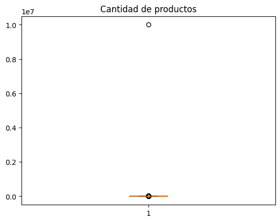

```python
%matplotlib inline
import matplotlib.pyplot as plt

fig1, ax1 = plt.subplots()
ax1.set_title('Cantidad de productos')
ax1.boxplot(np.array(detallesOrdenes.select('Cantidad').collect()))
```

```
{'whiskers': [<matplotlib.lines.Line2D at 0x7597ee491ad0>,
 'caps': [<matplotlib.lines.Line2D at 0x7597ee492b90>,
 'boxes': [<matplotlib.lines.Line2D at 0x7597f9e88b50>],
 'medians': [<matplotlib.lines.Line2D at 0x7597ee491110>],
 'fliers': [<matplotlib.lines.Line2D at 0x7597eecd7a10>],
 'means': []}
```

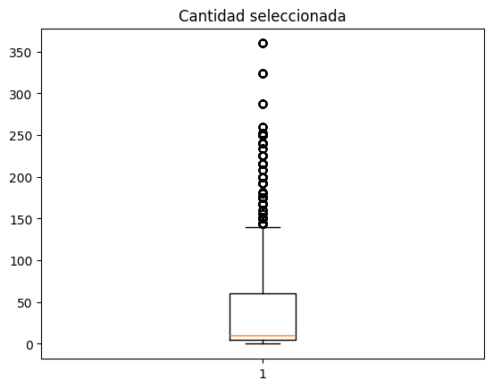

```python
fig1, ax1 = plt.subplots()
ax1.set_title('Cantidad seleccionada')

my_list = [float(i) for i in detallesOrdenes.select(f.collect_list('Cantidad_seleccionada')).first()[0]]
ax1.boxplot(my_list)
```

El análisis anterior es muy útil para variables de tipo numérico, sin embargo es incompleto para las variables de tipo caracter o las variables categoricas, por ende es necesario implementar nuestro propio código par obtener estadisticos como la moda y la mediana. A continuación obtenemos la moda para la variable Descripcion:

```python
detallesOrdenes.groupby("Descripcion").count().orderBy("count", ascending=False).show(5)
```

```
[Stage 71:>                                                         (0 + 1) / 1]
```

```
+--------------------+-----+
|         Descripcion|count|
+--------------------+-----+
|                   a| 3225|
|Halloween skull m...|  306|
|Large  replacemen...|  305|
|"The Gu" red shir...|  303|
|"The Gu" red shir...|  296|
+--------------------+-----+
only showing top 5 rows
```

## Análisis de calidad de datos

La calidad de los datos consiste en validar la idoneidad de los datos analizando varias dimensiones, entre las cuales resaltamos:

- Completitud: Datos que no existen o no se conocen
- Unicidad (Duplicidad): Datos que son idénticos en diferentes registros o registros con valores idénticos en atributos en los que no debería ocurrir
- Consistencia: Esta medida se define por la validez o integridad del dato, en la definición de su estructura, al interior de una fila o entre diferentes filas de la misma fuente o de diferentes fuentes. El manejo de unidades en los datos y el significado del dato son generadores de inconsistencias.
- Validez: a nivel de formato y de sentido de los datos más alla de sus valores

Para asegurar una calidad mínima de los datos en estas dimensiones hay que entender su origen y posteriormente realizar un proceso de validación de cada una de las dimensiones de perfilamiento que llevará a un entendimiento de los datos disponibles.

A continuación se definen dos funciones, la primera cuenta los valores vacios por columna de dataframe, la segunda retorna un diccionario de columnas con cardinalidad superior al 50%

Te invito a revisar los recursos de calidad de datos que hemos visto en el curso, a continuacion ejemplos daremos algunos ejemplos por cada dimensión para el caso del tutorial

### Unicidad y validez

La unicidad se revisó en la segunda regla de negocio y la validez se reviso en el perfilamiento general, en la regla de negocio 3 y en el análisis de la descripción al final de la sección de revisión de reglas de negocio

### Completitud y validez

```python
def contar_vacios(df):
    resultados = []
    for c in df.columns:
        vacios = df.filter(df[c].isNull()).count()
        if vacios!=0:
            print('número de vacíos para columna '+c+': '+str( vacios ))
            resultados.append(vacios)
    return resultados

def cardinalidad(df):
    resultado = {}
    for c in df.columns:
        cardinalidad = df.select(col(c)).distinct().count()
        if cardinalidad>=df.count()*0.5:
            resultado[c] = cardinalidad
    return resultado
```

```python
columnas_vacias_ordenes = contar_vacios(ordenes)
print('detalles de ordenes: ')
columnas_vacias_detalles = contar_vacios(detallesOrdenes)
```

```
número de vacíos para columna Seleccionado_por_ID_de_persona: 13570
```

```
número de vacíos para columna ID_de_pedido_pendiente: 79035
```

```
[Stage 104:>                                                        (0 + 1) / 1]
```

```
número de vacíos para columna Comentarios: 88258
```

```
número de vacíos para columna Instrucciones_de_entrega: 88258
```

```
número de vacíos para columna Comentarios_internos: 88258
```

```
número de vacíos para columna Seleccion_completada_cuando: 4347
detalles de ordenes:
número de vacíos para columna Precio_unitario: 983
número de vacíos para columna Seleccion_completada_cuando: 982
```

```python
columnas_alta_cardinalidad_ordenes = cardinalidad(ordenes)
columnas_alta_cardinalidad_detalles = cardinalidad(detallesOrdenes)
columnas_alta_cardinalidad_ordenes, columnas_alta_cardinalidad_detalles
```

```
({'ID_de_pedido': 54145}, {'Detalle_orden_ID': 57981, 'ID_de_pedido': 38742})
```

### Consistencia

A nivel de consistencia algunos ejemplos de revisión son precios negativos, productos que aparecen en las ordenes pero que no esten registrados en la tabla de produtos. En nuestro caso vamos a verificar que todas las ordenes tengan detalle de orden y viceversa

```python
#consistencia: revisar genially: definicion de consistencia
ids_ordenes = set([x.ID_de_pedido for x in ordenes.select('ID_de_pedido').collect()])
ids_detalles = set([x.ID_de_pedido for x in detallesOrdenes.select('ID_de_pedido').collect()])

len(ids_ordenes-ids_detalles), len(ids_detalles-ids_ordenes)
```

```
(44359, 28956)
```

Como se puede observar hay una diferencia de 44.359 ordenes que no tienen detalles y hay 28.956 detalles que no tienen orden. Ninguno de los casos tiene sentido en el contexto de WideWorldImporters. Esta inconsistencia se notifica al negocio dado que no hay forma de conocer cuáles son los registros que pueden tener ids que no existen

## Herramientas para facilitar el entendimiento de datos

Algunas de las estadísticas antes desarrolladas pueden obtenerse por medio de herramientas como Pandas Profiling una herramienta muy útil, *Pero no perfecta ni completa*, es Pandas profiling que dado un conjunto de datos, nos muestra histogramas, estadísticas etc. A continuación guardamos el reporte en html

```python
reporte = ProfileReport(ordenes.toPandas())
reporte.to_file(PATH+"reporte_prefilamiento.html")
```

```
  series = series.fillna(np.nan)
  series = series.fillna(np.nan)
  discretized_df.loc[:, column] = self._discretize_column(
```

Lo primero que hay que notar es que hay 3 secciones principales. La primera es un resumen, la segunda es un análisis por cada variable y luego tenemos interacciones y correlaciones entre variables.

Sección de variables del reporte:

5. Note que para cada variable nos dan estadisticos como la media, mínimo y máximo asi como un histograma de distribución de la variable, para nuestros datos no observamos nada por fuera de lo comun. (Como valores extremos)
6. La variable ID_de_pedido tiene 61.3% de valores distintos, es decir, es una variable con alta cardinalidad. Este tipo de variables no aportan a las relaciones entre filas o columnas, por lo que suelen no ser útiles a la hora de hacer análitica.
7. La variable ID_cliente tiene solo el 0,8% de valores distintos, es decir que las ordenes que tenemos parecen ser de pocos clientes, pero que podrían ser recurrentes o fieles
8. Hay 10 empleados en los datos de ordenes
9. Seleccionado_por_ID_persona tiene 15,4% de datos vacíos, no es muy alto pero podríamos eliminarla si no es importante. Preguntar al negocio
10. ID_de_pedido_pendiente tiene un porcentaje de 89,5% de valores vacíos, es casi constante y las columnas constantes no aportan a los análisis, preguntar al negocio si hay algún inconveniente en borrar esta columna
11. Hay 1512 Fecha_de_pedido distintos, siendo el 3 de febrero del 2015 una de las fechas con más número de ordenes
12. Fecha_de_entrega_esperada y Seleccion_completada_cuando tienen alta cardinalidad

Sección de interacciones y correlaciones:

Parecen haber columnas con correlaciones(Spearman) iguales a 1, esto significa que ambas columnas representan la misma información, idealmente no queremos columnas "repetidas", un ejemplo es ID_cliente y ID_de_persona_de_contacto, decidimos preguntarle al negocio si es necesario mantener ambas columnas

**Cabe aclarar que un pandas profiling sin interpretación no es suficiente como análisis para realizar el entendimiento de los datos.**

Así mismo, recuerde que si es necesario, se debe utilizar otra herramienta (código, visualizaciones, etc) para poder completar el análisis estadístico.

### Algunas gráficas utiles: Diagrama de caja, dispersion, histogramas para entender las distribuciones de las variables

Generalmente las gráficas se emplean para entender la distribución de cada variable, también sirven para visualizar la relación entre 2 o más variables

Algunas gráficas útiles son los histogramas, disepersión, diagramas de caja. Hay varias maneras de implementarlos, con paquetes como matplotlib o pandas, con funciones propias de pyspark, etc, a continuacón mostramos cómo hacerlo a travez de pandas

```
array([[<Axes: title={'center': 'Cantidad_seleccionada'}>]], dtype=object)
```

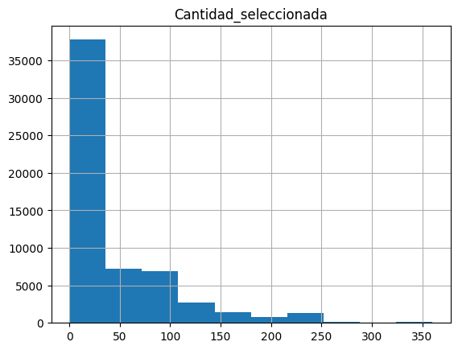

```python
#para valores extremos(subir a calidad)
detallesOrdenes.toPandas().hist(column='Cantidad_seleccionada')
```

```python
cantidades = detallesOrdenes.groupby("Cantidad").count().orderBy("count", ascending=False)
```

Como se puede observar, el método retorna un dataframe, que vamos a usar para obtener dos arreglos, uno con el rango de cada una de las barras y otro con la cantidad de registros por rango. Se puede usar Matplotlib para graficar esta información:

[figure not shown]

```python
def plotHistogramData(data):
    binSides, binCounts = [row[0] for row in data.collect()], [row[1] for row in data.collect()]
    binSides = [round(i, 2) for i in binSides]
    N = len(binCounts)
    ind = np.arange(N)
    width = 1

    fig, ax = plt.subplots()
    rects1 = ax.bar(ind+0.5, binCounts, width, color='b')

    fig.set_size_inches(1.3*N, 8)

    ax.set_ylabel('Frecuencia')
    ax.set_xlabel('Rango')
    ax.set_title('Histograma')
    ax.set_xticks(np.arange(N))
    ax.set_xticklabels(binSides)

    plt.show()

plotHistogramData(cantidades)
```

El diagrama de dispersion, nos muestra los datos para dos variables en forma de puntos y es muy útil para entender la relación entre dichas variables

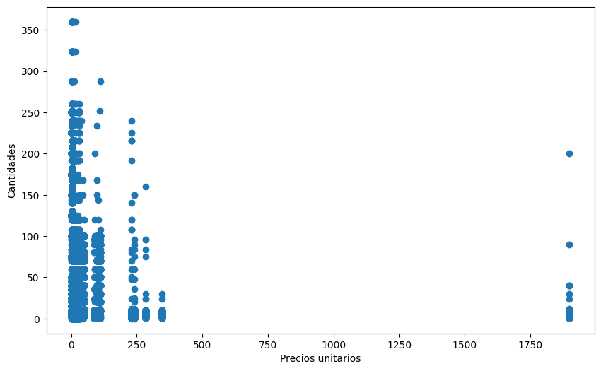

```python
unitPrices = [row['Precio_unitario'] for row in detallesOrdenes.select(col('Precio_unitario')).collect()]
quantities = [row['Cantidad_seleccionada'] for row in detallesOrdenes.collect()]

fig, ax = plt.subplots(figsize=(10, 6))
ax.scatter(x = unitPrices, y = quantities)
plt.xlabel("Precios unitarios")
plt.ylabel("Cantidades")

plt.show()
```

### Otras opciones de exploración

PySpark también da la opción de crear tablas de pivotes. En el siguiente ejemplo, se muestra cómo hacer una tabla que permite ver cuántas ordenes hay por cada *Fecha_de_pedido* y por cada *ID_de_vendedor*, es decir por fecha y por empleado cuantas ordenes existen:

```python
ordenes.groupBy('Fecha_de_pedido').pivot('ID_de_vendedor').count().show()
```

```
[Stage 387:>                                                        (0 + 1) / 1]
```

```
+---------------+----+---+---+----+----+----+---+----+---+----+
|Fecha_de_pedido|   2|  3|  6|   7|   8|  13| 14|  15| 16|  20|
+---------------+----+---+---+----+----+----+---+----+---+----+
|     2014-12-13|   7|  8|  7|   5|   3|   6|  7|   6|  2|   6|
|     2014-05-27|   6|  7|  8|   6|   2|  11|  6|   5| 13|   6|
|     2014-02-22|   6|  4|  2|   6|   4|   3|  2|NULL| 11|   7|
|     2015-05-01|  22| 13| 17|   2|  14|  13|  9|  11| 19|  16|
|    Feb 27,2014|   5|  3|  6|   1|   3|NULL|  3|   3|  7|   1|
|     2015-02-09|   2| 13| 15|  18|   8|   6|  6|   7| 15|  15|
|    Sep 21,2015|   2|  6|  7|   6|   2|   2|  3|   3|  3|   2|
|     2014-07-14|  13| 10| 15|   7|   5|  13| 15|  10| 17|  12|
|    Jul 26,2014|   2|  2|  3|   3|   1|   1|  3|NULL|  1|   2|
|    May 14,2016|NULL|  3|  2|   5|   1|   4|  3|NULL|  1|   3|
|    Aug 22,2015|   1|  1|  2|   4|NULL|   2|  2|   2|  5|   1|
|     2014-12-11|  13| 18|  4|   4|   9|  10|  2|  11|  5|   2|
|     2015-02-27|  19| 14| 10|  10|  22|  19| 17|  17|  9|  18|
|     2016-04-22|   7| 19|  5|   5|   5|   4|  7|  12| 12|  19|
|    Jan 03,2015|NULL|  1|  4|   1|   3|   1|  1|NULL|  2|NULL|
|     2015-02-28|   9|  4|  5|   6|   5|  13|  8|   3|  8|   8|
|     2015-11-20|  11|  6| 11|  10|  23|  15| 15|   9| 16|  21|
|    Mar 25,2015|NULL|  2|  5|   4|   3|   5|  2|   4|  3|   3|
|     2016-05-21|   3|  4|  3|NULL|   1|   3|  3|   6|  4|   1|
|    Oct 14,2014|   4|  4|  3|   1|   4|   4|  5|   5|  1|   3|
+---------------+----+---+---+----+----+----+---+----+---+----+
only showing top 20 rows
```

Otro análisis muy útil es el de la correlación lineal entre dos variables, para ver la matriz de correlacion que mide esta dependencia o la fuerza de la relación lineal entre dos variables vamos a usar pandas, la interpretación es que si entre dos variables A y B el valor obtenido es cercano a -1 o a 1, se interpreta como que A y B contienen la misma información y por ende no es necesario mantener ambas columnas

```python
df = detallesOrdenes.toPandas()

corr = df.select_dtypes(include=['number']).corr(method='pearson')

corr.style.background_gradient(cmap='coolwarm')
```

|  | Detalle_orden_ID | ID_de_pedido | ID_Producto | ID_Tipo_Paquete | Cantidad | Cantidad_seleccionada |
| --- | --- | --- | --- | --- | --- | --- |
| Detalle_orden_ID | 1.000000 | 0.052772 | 0.022949 | nan | 0.003160 | 0.003761 |
| ID_de_pedido | 0.052772 | 1.000000 | -0.007438 | nan | -0.003613 | -0.008976 |
| ID_Producto | 0.022949 | -0.007438 | 1.000000 | nan | 0.002252 | 0.513602 |
| ID_Tipo_Paquete | nan | nan | nan | nan | nan | nan |
| Cantidad | 0.003160 | -0.003613 | 0.002252 | nan | 1.000000 | -0.001033 |
| Cantidad_seleccionada | 0.003761 | -0.008976 | 0.513602 | nan | -0.001033 | 1.000000 |

## Conclusiones/resultados

**Conclusiones generales:**

1. En la tabla de ordenes tenemos información **relacionada con el cliente, el empleado y con la órden**. Por otra parte, en los detalles de ordenes se tiene **información del pedido y del producto**
2. Una fila de órdenes representa la órden realizada por un cliente y atendida por un empleado. Mientras que el detalle de órden coincide con su nombre y contiene el detalle de cada producto solicitado en una órden.
3. ¿cuál es la diferencia entre cantidad y cantidad seleccionada?

**Conclusiones de reglas de negocio:**

1. La regla 1 no es completamente cierta, pues en los datos no hay ningun registro con tasa_de_impuesto de 10%, es necesario pedir aclaraciones al negocio en relación a este descubrimiento
2. La regla 2 no es cierta dado que el número de registros no parece coincidir con el número dado por el negocio, Hay 14.079 ordenes completamente repetidas y 258 registros que representan el mismo detalle de orden pero con valores distintos, los primeros se pueden eliminar, pero ¿qué deberíamos hacer con los segundos?
3. Los datos comienzan en enero 1 de 2014, sin embargo la regla 2 nos dice que debería ser desde 2013, ¿es un error o faltan datos?
4. Algunos formatos de fecha no coinciden con el dado en la regla 3, por ejemplo del atributo Fecha_de_pedido hay 20 mil registros que no tienen ese formato. En este caso el cambio de formato se puede implementar, ¿estan de acuerdo?
5. La descripcion de algunos productos es "a", ¿esto es correcto?

**Conclusiones de calidad:**

**Usando herramientas:**

Sección de variables del reporte:

5. Note que para cada variable nos dan estadisticos como la media, mínimo y máximo asi como un histograma de distribución de la variable, para nuestros datos no observamos nada por fuera de lo comun. (Como valores extremos)
6. La variable ID_de_pedido tiene 61.3% de valores distintos, es decir, es una variable con alta cardinalidad. Este tipo de variables no aportan a las relaciones entre filas o columnas, por lo que suelen no ser útiles a la hora de hacer análitica.
7. La variable ID_cliente tiene solo el 0,8% de valores distintos, es decir que las ordenes que tenemos parecen ser de pocos clientes, pero que podrían ser recurrentes o fieles
8. Hay 10 empleados en los datos de ordenes
9. Seleccionado_por_ID_persona tiene 15,4% de datos vacíos, no es muy alto pero podríamos eliminarla si no es importante. Preguntar al negocio
10. ID_de_pedido_pendiente tiene un porcentaje de 89,5% de valores vacíos, es casi constante y las columnas constantes no aportan a los análisis, preguntar al negocio si hay algún inconveniente en borrar esta columna
11. Hay 1512 Fecha_de_pedido distintos, siendo el 3 de febrero del 2015 una de las fechas con más número de ordenes
12. Fecha_de_entrega_esperada y Seleccion_completada_cuando tienen alta cardinalidad

Sección de correlación:

13. Parecen haber columnas con correlaciones(Spearman) iguales a 1, esto significa que ambas columnas representan la misma información, idealmente no queremos columnas "repetidas", un ejemplo es ID_cliente y ID_de_persona_de_contacto, decidimos preguntarle al negocio si es necesario mantener ambas columnas

**Conclusiones de consultoria**

[figure not shown]

Teniendo en cuenta el requerimiento de WWI, consideramos que es posible llevar a cabo una solucióon pues contamos con la información necesaria especificada en el análisis requerido, sin embargo es necesario realizar correcciones a los datos y obtener aclaraciones de parte del negocio para entender completamente la necesidad de negocio

Para comprobar su comprensión de esta sección, lo invitamos a responder la pregunta:

```
¿Qué funcionalidades de PySpark puedo utilizar para realizar el entendimiento de datos y cómo las puedo utilizar?
```

Como parte de nuestro trabajo es preveer posibles soluciones a las conclusiones de perfilamiento, por ende lo invitamos a responder:

```
¿Qué métodos podría utilizar para reemplazar los valores nulos de una columna por el promedio de la misma?
```

# 1. ¿Qué funcionalidades de PySpark puedo utilizar para realizar el entendimiento de datos y cómo las puedo utilizar?

El entendimiento de datos es una etapa fundamental dentro de cualquier proyecto analítico, ya que permite conocer la estructura, contenido, calidad y comportamiento de los datos antes de realizar procesos de transformación, modelado o visualización. PySpark proporciona múltiples funcionalidades que facilitan este proceso sobre grandes volúmenes de información.

## Inspección de la estructura de los datos

### `printSchema()`

Permite visualizar el esquema del DataFrame, incluyendo el nombre de las columnas, sus tipos de datos y si aceptan valores nulos.

```
df.printSchema()
```

Esta función es útil para identificar tipos de datos incorrectos, detectar columnas numéricas, categóricas o de fecha y verificar la estructura general de la información.

### `columns`

Permite obtener la lista de columnas del DataFrame.

```
df.columns
```

Es útil para conocer rápidamente la estructura de la tabla y facilitar la selección de variables para análisis posteriores.

## Exploración inicial de registros

### `show()`

Permite visualizar una muestra de registros.

```
df.show(10)
```

Esta función ayuda a comprender el significado de una fila, detectar formatos inesperados y validar que la carga de datos se realizó correctamente.

### `count()`

Permite conocer la cantidad total de registros.

```
df.count()
```

Es útil para validar reglas de negocio y comparar el volumen real de datos contra el volumen esperado.

## Estadísticas descriptivas

### `describe()`

Calcula estadísticas básicas para columnas numéricas.

```
df.describe().show()
```

Genera indicadores como:

- Cantidad de registros
- Promedio
- Desviación estándar
- Valor mínimo
- Valor máximo

Estas métricas permiten identificar valores atípicos y comprender la distribución de los datos.

### `summary()`

Extiende las estadísticas descriptivas incluyendo percentiles.

```
df.summary().show()
```

Es útil para analizar la dispersión de los datos y detectar posibles valores extremos.

## Análisis de valores únicos

### `distinct()`

Permite identificar valores únicos dentro de una columna.

```
df.select("ProveedorID").distinct().count()
```

Es útil para validar cardinalidades y verificar reglas de negocio relacionadas con cantidades esperadas de clientes, proveedores o productos.

## Agrupación y análisis de frecuencia

### `groupBy()`

Permite agrupar información y calcular métricas por categoría.

```
df.groupBy("ProveedorID").count().show()
```

Esta funcionalidad permite analizar distribuciones, identificar categorías dominantes y detectar comportamientos inusuales.

### `agg()`

Permite realizar agregaciones sobre una o varias columnas.

```
from pyspark.sql.functions import *

df.agg(
    count("*").alias("TotalRegistros"),
    avg("Cantidad").alias("PromedioCantidad"),
    max("Cantidad").alias("CantidadMaxima")
).show()
```

Es útil para construir indicadores generales y validar reglas de negocio.

## Filtrado y validación de reglas

### `filter()` o `where()`

Permite seleccionar registros que cumplan una condición específica.

```
df.filter(col("Cantidad") > 50000000).show()
```

Es especialmente útil para validar reglas de negocio y detectar registros potencialmente erróneos.

## Ordenamiento

### `orderBy()`

Permite ordenar los registros.

```
df.orderBy(col("Cantidad").desc()).show()
```

Facilita la identificación de valores máximos, mínimos y posibles anomalías.

## Evaluación de calidad de datos

### Detección de valores nulos

```
df.filter(col("Cantidad").isNull()).count()
```

Permite medir la completitud de los datos e identificar información faltante.

### Detección de duplicados

```
df.dropDuplicates().count()
```

Permite evaluar la unicidad de los registros y detectar posibles problemas de integración o carga de información.

### Validación de formatos de fecha

```
from pyspark.sql.functions import to_timestamp

df = df.withColumn(
    "FechaMovimiento",
    to_timestamp("FechaMovimiento","yyyy-MM-dd HH:mm:ss")
)
```

Permite validar que las fechas cumplan con el formato definido por el negocio.

## Conclusión

PySpark ofrece un conjunto amplio de funcionalidades para realizar el entendimiento de datos. Mediante herramientas de exploración, análisis estadístico, validación de reglas de negocio y evaluación de calidad, es posible identificar tempranamente problemas en los datos y generar recomendaciones para su limpieza y preparación antes de desarrollar modelos analíticos o tableros de control.

# 2. ¿Qué métodos podría utilizar para reemplazar los valores nulos de una columna por el promedio de la misma?

Los valores nulos representan uno de los problemas más comunes en calidad de datos. Cuando una variable numérica contiene información faltante, una alternativa frecuente consiste en reemplazar dichos valores por el promedio de la misma columna, con el fin de conservar los registros y evitar la pérdida de información.

## Método 1: Calcular el promedio y utilizar `fillna()`

Primero se calcula el promedio de la columna:

```
from pyspark.sql.functions import avg

promedio = df.select(
    avg("Cantidad")
).first()[0]
```

Posteriormente se reemplazan los valores nulos:

```
df = df.fillna({
    "Cantidad": promedio
})
```

Este método es sencillo, eficiente y ampliamente utilizado cuando el porcentaje de valores faltantes es bajo.

## Método 2: Utilizar `withColumn()` y `when()`

También es posible reemplazar los valores nulos utilizando una condición explícita.

```
from pyspark.sql.functions import when, col

df = df.withColumn(
    "Cantidad",
    when(
        col("Cantidad").isNull(),
        promedio
    ).otherwise(col("Cantidad"))
)
```

Este método ofrece mayor flexibilidad y permite incorporar reglas de negocio adicionales.

## Método 3: Utilizar consultas SQL de Spark

Si se trabaja mediante SQL, la imputación puede realizarse utilizando expresiones condicionales.

```
SELECT
    CASE
        WHEN Cantidad IS NULL THEN (
            SELECT AVG(Cantidad)
            FROM movimientos
        )
        ELSE Cantidad
    END AS Cantidad
FROM movimientos
```

Este enfoque es útil cuando la organización utiliza principalmente consultas SQL dentro de sus procesos de transformación.

## Consideraciones antes de reemplazar valores nulos

Antes de realizar cualquier imputación es importante analizar el significado de los datos faltantes.

Por ejemplo:

- Determinar qué porcentaje de registros presenta valores nulos.
- Validar con el negocio si un valor nulo representa ausencia de información o un error de captura.
- Verificar si reemplazar por el promedio puede generar sesgos en los análisis.
- Evaluar si es más adecuado utilizar otros métodos de imputación o eliminar los registros afectados.

## Conclusión

PySpark proporciona diferentes mecanismos para reemplazar valores nulos por el promedio de una columna, siendo `fillna()` la alternativa más sencilla y utilizada. Sin embargo, antes de aplicar cualquier técnica de imputación es fundamental comprender el contexto de negocio y evaluar el impacto que dicha modificación puede tener sobre los resultados analíticos y la calidad de la información.

# 5. Tarea

Espacio para desarrollar la tarea propuesta

### Perfilamiento de datos

```python
sql_movimientos = "(SELECT * FROM movimientosCopia) movimientosCopia"

movimientos = obtener_dataframe_de_bd(
    db_connection_string,
    sql_movimientos,
    db_user,
    db_psswd
)
```

```python
movimientos.printSchema()

movimientos.show(5)

print("Filas:", movimientos.count())

print("Columnas:", len(movimientos.columns))
```

```
root
 |-- TransaccionProductoID: integer (nullable = true)
 |-- ProductoID: integer (nullable = true)
 |-- TipoTransaccionID: integer (nullable = true)
 |-- ClienteID: double (nullable = true)
 |-- InvoiceID: double (nullable = true)
 |-- ProveedorID: string (nullable = true)
 |-- OrdenDeCompraID: string (nullable = true)
 |-- FechaTransaccion: string (nullable = true)
 |-- Cantidad: double (nullable = true)
```

```
+---------------------+----------+-----------------+---------+---------+-----------+---------------+----------------+--------+
|TransaccionProductoID|ProductoID|TipoTransaccionID|ClienteID|InvoiceID|ProveedorID|OrdenDeCompraID|FechaTransaccion|Cantidad|
+---------------------+----------+-----------------+---------+---------+-----------+---------------+----------------+--------+
|               118903|       217|               10|    476.0|  24904.0|           |               |     Apr 25,2014|   -40.0|
|               286890|       135|               10|     33.0|  60117.0|           |               |     Dec 10,2015|    -7.0|
|               285233|       111|               10|    180.0|  59768.0|           |               |     Dec 04,2015|    -2.0|
|               290145|       213|               10|     33.0|  60795.0|           |               |     Dec 23,2015|    -3.0|
|               247492|        90|               10|     55.0|  51851.0|           |               |     Jul 27,2015|   -24.0|
+---------------------+----------+-----------------+---------+---------+-----------+---------------+----------------+--------+
only showing top 5 rows
```

```
[Stage 397:>                                                        (0 + 1) / 1]
```

```
Filas: 204292
Columnas: 9
```

## Significado de una fila

Cada fila de la tabla `movimientosCopia` representa un movimiento de inventario asociado a un producto específico dentro de la operación de Wide World Importers.

El registro almacena información relacionada con el producto involucrado, el tipo de transacción que originó el movimiento, las entidades asociadas a la operación (cliente o proveedor), los documentos de soporte de la transacción (factura u orden de compra), la fecha en que ocurrió el movimiento y la cantidad de unidades afectadas.

Dependiendo del tipo de transacción, el movimiento puede representar una entrada o salida de inventario, permitiendo reconstruir la evolución histórica de las existencias de los productos.

## Estructura de los datos

La tabla `movimientosCopia` está compuesta por 9 atributos:

| Campo | Tipo de dato |
| --- | --- |
| TransaccionProductoID | Integer |
| ProductoID | Integer |
| TipoTransaccionID | Integer |
| ClienteID | Double |
| InvoiceID | Double |
| ProveedorID | String |
| OrdenDeCompraID | String |
| FechaTransaccion | String |
| Cantidad | Double |

Los atributos permiten identificar la transacción realizada, el producto involucrado, las entidades relacionadas y la cantidad de unidades movidas.

Se observa la presencia de variables numéricas, variables categóricas y una variable temporal (`FechaTransaccion`) que registra el momento en que ocurrió el movimiento.

```python
movimientos.describe().show()
```

```
[Stage 433:>                                                        (0 + 1) / 1]
```

```
+-------+---------------------+------------------+-------------------+------------------+-----------------+-----------------+------------------+--------------------+-----------------+
|summary|TransaccionProductoID|        ProductoID|  TipoTransaccionID|         ClienteID|        InvoiceID|      ProveedorID|   OrdenDeCompraID|    FechaTransaccion|         Cantidad|
+-------+---------------------+------------------+-------------------+------------------+-----------------+-----------------+------------------+--------------------+-----------------+
|  count|               204292|            204292|             204292|            204292|           204292|           204292|            204292|              204292|           204292|
|   mean|   212458.04047637695|110.70090850351458| 10.035253460732676| 517.3252941867523|42957.26929590978|4.951898734177215|1345.9973277074544|                NULL|719.4997650421946|
| stddev|    71352.37579752573| 63.49014746219581|0.18563716955046372|353.50136995999276| 16826.9772221931|1.406311225432683|420.37740964792835|                NULL| 4729.36659747762|
|    min|                89146|                 1|                 10|               0.0|              0.0|                 |                  |2013-12-31 07:00:...|           -360.0|
|    max|               336251|               227|                 12|            1061.0|          70510.0|              7.0|             999.0|         Sep 30,2015|          67368.0|
+-------+---------------------+------------------+-------------------+------------------+-----------------+-----------------+------------------+--------------------+-----------------+
```

## Estadísticas descriptivas

Se realizó un análisis descriptivo de las variables numéricas de la tabla con el fin de comprender la distribución general de los movimientos de inventario.

### ProductoID

Los movimientos registrados involucran productos identificados mediante códigos entre 1 y 227, lo que indica la participación de una cantidad importante de productos dentro de la operación analizada.

### TipoTransaccionID

Los registros corresponden a tres tipos de transacción diferentes, identificados mediante valores comprendidos entre 10 y 12.

### ClienteID

Los movimientos están asociados a clientes identificados mediante códigos entre 0 y 1.061.

### InvoiceID

Los identificadores de factura se encuentran entre 0 y 70.510, evidenciando un amplio número de documentos asociados a los movimientos registrados.

### Cantidad

La variable `Cantidad` presenta las siguientes características:

- Valor mínimo: -360 unidades
- Valor máximo: 67.368 unidades
- Promedio: 719 unidades
- Desviación estándar: 4.729 unidades

La diferencia entre el valor mínimo y máximo evidencia una alta variabilidad en las cantidades movilizadas. Adicionalmente, la desviación estándar es significativamente superior al promedio, indicando una dispersión importante entre las transacciones registradas.

```python
from pyspark.sql.functions import countDistinct

movimientos.select(
    countDistinct("ClienteID").alias("Clientes"),
    countDistinct("ProveedorID").alias("Proveedores"),
    countDistinct("ProductoID").alias("Productos"),
    countDistinct("TipoTransaccionID").alias("TiposTransaccion")
).show()
```

```
[Stage 436:>                                                        (0 + 1) / 1]
```

```
+--------+-----------+---------+----------------+
|Clientes|Proveedores|Productos|TiposTransaccion|
+--------+-----------+---------+----------------+
|     664|          4|      227|               3|
+--------+-----------+---------+----------------+
```

## Cardinalidad de las entidades

Con el fin de comprender la diversidad de información almacenada en la tabla, se calculó la cantidad de valores únicos presentes en las principales entidades involucradas en los movimientos de inventario.

| Entidad | Cantidad de valores únicos |
| --- | --- |
| Clientes | 664 |
| Proveedores | 4 |
| Productos | 227 |
| Tipos de transacción | 3 |

### Clientes

Se identificaron 664 clientes distintos asociados a los movimientos registrados. Esto indica que los movimientos de inventario están relacionados con una base amplia de clientes dentro del período analizado.

### Productos

Se identificaron movimientos para 227 productos distintos. Este resultado muestra que la totalidad o gran parte del catálogo de productos participa en las operaciones de inventario registradas.

### Tipos de transacción

Se observaron 3 tipos de transacción diferentes, lo que sugiere que los movimientos de inventario se generan a partir de un conjunto limitado de procesos operativos.

```python
movimientos.select("Cantidad").summary().show()
```

```
[Stage 442:>                                                        (0 + 1) / 1]
```

```
+-------+-----------------+
|summary|         Cantidad|
+-------+-----------------+
|  count|           204292|
|   mean|719.4997650421946|
| stddev| 4729.36659747762|
|    min|           -360.0|
|    25%|            -60.0|
|    50%|             -9.0|
|    75%|             -5.0|
|    max|          67368.0|
+-------+-----------------+
```

## Distribución de la variable Cantidad

La variable `Cantidad` representa el número de unidades afectadas por cada movimiento de inventario.

Se calcularon medidas de posición para comprender mejor su distribución:

| Medida | Valor |
| --- | --- |
| Mínimo | -360 |
| Percentil 25 | -60 |
| Mediana (Percentil 50) | -9 |
| Percentil 75 | -5 |
| Máximo | 67.368 |
| Promedio | 719 |
| Desviación estándar | 4.729 |

Los resultados muestran una distribución altamente asimétrica. Mientras que la mayoría de los movimientos presentan cantidades negativas relativamente pequeñas, existen algunos movimientos con cantidades positivas considerablemente mayores.

La diferencia observada entre la mediana (-9) y el promedio (719) evidencia que los valores extremos tienen una influencia importante sobre la distribución general de la variable.

Asimismo, el rango de valores observados se extiende desde -360 hasta 67.368 unidades, indicando una amplia variabilidad en el tamaño de los movimientos registrados.

```python
movimientos.groupBy("TipoTransaccionID").count().show()
```

```
[Stage 445:>                                                        (0 + 1) / 1]
```

```
+-----------------+------+
|TipoTransaccionID| count|
+-----------------+------+
|               12|    46|
|               10|197136|
|               11|  7110|
+-----------------+------+
```

## Distribución de los tipos de transacción

Con el fin de comprender la composición de los movimientos registrados, se analizó la distribución de los registros por tipo de transacción.

| TipoTransaccionID | Cantidad de movimientos | Participación |
| --- | --- | --- |
| 10 | 197.136 | 96,50% |
| 11 | 7.110 | 3,48% |
| 12 | 46 | 0,02% |

Los resultados muestran una fuerte concentración de movimientos en el tipo de transacción 10, el cual representa más del 96% de todos los registros analizados.

Por su parte, el tipo de transacción 11 participa con una proporción considerablemente menor, mientras que el tipo de transacción 12 presenta una frecuencia extremadamente baja dentro del conjunto de datos.

Esta distribución evidencia que la mayor parte de la actividad operativa registrada en la tabla está asociada a un único tipo de transacción.

# Conclusión General del Perfilamiento de Datos

La tabla `movimientosCopia` almacena información transaccional relacionada con movimientos de inventario, incluyendo productos, clientes, proveedores, documentos asociados, fechas y cantidades movilizadas.

El conjunto de datos está conformado por 204.292 registros y 9 atributos, proporcionando un volumen adecuado para realizar análisis sobre el comportamiento de inventarios y la operación logística de la organización.

La variable Cantidad presenta una distribución heterogénea, caracterizada por movimientos de diferentes magnitudes y una marcada asimetría entre los valores observados. Adicionalmente, se identificó una alta concentración de registros en el tipo de transacción 10, el cual representa aproximadamente el 96,5% de los movimientos analizados.

Finalmente, se evidenció que la tabla no presenta valores nulos en ninguna de sus columnas, lo que facilita la ejecución de análisis posteriores sobre calidad de datos y validación de reglas de negocio.

### Análisis de calidad de datos

```python
from pyspark.sql.functions import countDistinct

movimientos.select(
    countDistinct("TransaccionProductoID").alias("IdsUnicos")
).show()

print("Total registros:", movimientos.count())
```

```
+---------+
|IdsUnicos|
+---------+
|   173659|
+---------+
```

```
[Stage 463:>                                                        (0 + 1) / 1]
```

```
Total registros: 204292
```

```python
duplicados = movimientos.count() - movimientos.dropDuplicates().count()

print("Registros duplicados:", duplicados)
```

```
[Stage 469:>                                                        (0 + 1) / 1]
```

```
Registros duplicados: 30633
```

# Calidad de Datos

## Dimensión: Unicidad

### Objetivo

Validar que cada movimiento de inventario sea identificado de manera única dentro de la tabla y determinar la existencia de registros duplicados.

### Validación realizada

Se comparó la cantidad total de registros con la cantidad de identificadores únicos (`TransaccionProductoID`) presentes en la tabla.

| Métrica | Valor |
| --- | --- |
| Registros totales | 204.292 |
| Identificadores únicos | 173.659 |
| Diferencia | 30.633 |

Adicionalmente, se realizó una validación de registros duplicados utilizando la función `dropDuplicates()`.

| Métrica | Valor |
| --- | --- |
| Registros duplicados | 30.633 |

### Hallazgo

Se identificaron 30.633 registros duplicados dentro de la tabla, equivalentes aproximadamente al 15% del total de observaciones analizadas.

Asimismo, el identificador `TransaccionProductoID` no presenta unicidad completa, ya que la cantidad de identificadores únicos es inferior al número total de registros.

### Impacto para el negocio

La existencia de registros duplicados puede generar:

- Sobreestimación de movimientos de inventario.
- Distorsión de indicadores operativos.
- Errores en cálculos de entradas y salidas de productos.
- Resultados incorrectos en tableros de control y análisis históricos.
- Problemas en procesos de conciliación y auditoría.

### Posibles alternativas de limpieza

- Eliminar registros completamente duplicados mediante procesos de deduplicación.
- Validar con el negocio si múltiples registros con el mismo `TransaccionProductoID` representan eventos legítimos o errores de carga.
- Definir una llave primaria de negocio que garantice la unicidad de cada movimiento.

### Conclusión

La dimensión de unicidad no se cumple satisfactoriamente en la tabla analizada, debido a la presencia de 30.633 registros duplicados. Antes de utilizar esta información para análisis o construcción de indicadores, será necesario validar la naturaleza de dichos duplicados y aplicar estrategias de depuración.

```python
from pyspark.sql.functions import col

print("ClienteID = 0:", movimientos.filter(col("ClienteID") == 0).count())

print("InvoiceID = 0:", movimientos.filter(col("InvoiceID") == 0).count())

print("ProveedorID vacío:", movimientos.filter(col("ProveedorID") == "").count())

print("OrdenDeCompraID vacío:", movimientos.filter(col("OrdenDeCompraID") == "").count())
```

```
ClienteID = 0: 7156
```

```
InvoiceID = 0: 7156
```

```
ProveedorID vacío: 197182
```

```
[Stage 484:>                                                        (0 + 1) / 1]
```

```
OrdenDeCompraID vacío: 197182
```

## Dimensión: Completitud

### Objetivo

Validar que la información requerida por el negocio se encuentre presente en los registros y determinar la existencia de valores faltantes o valores por defecto que puedan afectar los análisis posteriores.

### Validación realizada

Inicialmente se verificó la existencia de valores nulos en todas las columnas de la tabla, sin encontrar registros nulos.

Posteriormente se analizaron valores que podrían representar ausencia de información a pesar de no estar almacenados como nulos.

| Campo | Registros con valor por defecto o vacío |
| --- | --- |
| ClienteID = 0 | 7.156 |
| InvoiceID = 0 | 7.156 |
| ProveedorID vacío | 197.182 |
| OrdenDeCompraID vacío | 197.182 |

### Hallazgo

Aunque la tabla no presenta valores nulos, se identificaron múltiples registros con valores que podrían representar ausencia de información.

En particular:

- 7.156 registros presentan ClienteID igual a cero.
- 7.156 registros presentan InvoiceID igual a cero.
- 197.182 registros presentan ProveedorID vacío.
- 197.182 registros presentan OrdenDeCompraID vacío.

Los campos ProveedorID y OrdenDeCompraID presentan información únicamente en una pequeña proporción de los registros.

### Impacto para el negocio

Si los valores cero o vacíos representan información faltante, podrían generarse limitaciones para:

- Analizar correctamente la relación entre movimientos y proveedores.
- Realizar trazabilidad de órdenes de compra.
- Construir indicadores asociados a proveedores.
- Ejecutar procesos de conciliación o auditoría.

No obstante, también es posible que estos campos sean opcionales dependiendo del tipo de transacción registrado. Esta situación deberá ser validada con el negocio.

### Preguntas para el negocio

1. ¿ClienteID = 0 representa ausencia de cliente o corresponde a un valor válido del sistema?
2. ¿InvoiceID = 0 representa ausencia de factura o corresponde a una transacción especial?
3. ¿ProveedorID vacío es esperado para ciertos tipos de movimiento?
4. ¿OrdenDeCompraID vacío es esperado para determinados procesos operativos?
5. ¿Qué campos son obligatorios para cada TipoTransaccionID?

### Posibles alternativas de limpieza

- Reemplazar valores cero por nulos cuando representen ausencia de información.
- Definir reglas de obligatoriedad por tipo de transacción.
- Implementar controles de calidad que validen la presencia de información requerida antes de registrar nuevos movimientos.

### Conclusión

La tabla presenta completitud física del 100% al no contener valores nulos. Sin embargo, se identificaron valores cero y cadenas vacías que podrían representar información faltante desde una perspectiva de negocio. Será necesario validar el significado de estos valores antes de utilizar la información en procesos analíticos o de reportería.

```python
movimientos.filter(col("Cantidad") > 50000000).count()
```

```
0
```

```python
movimientos.selectExpr(
    "max(Cantidad) as CantidadMaxima"
).show()
```

```
[Stage 490:>                                                        (0 + 1) / 1]
```

```
+--------------+
|CantidadMaxima|
+--------------+
|       67368.0|
+--------------+
```

## Dimensión: Validez

### Objetivo

Validar el cumplimiento de las reglas de negocio definidas por la organización para los movimientos de inventario.

De acuerdo con la información suministrada por Wide World Importers:

> "La cantidad máxima de productos movidos es de 50 millones por transacción."

### Validación realizada

Se verificó la existencia de movimientos cuya cantidad superara el límite máximo permitido de 50.000.000 unidades.

| Métrica | Resultado |
| --- | --- |
| Movimientos superiores a 50 millones | 0 |
| Cantidad máxima observada | 67.368 |

### Hallazgo

No se identificaron registros que incumplan la regla de negocio definida por la organización.

La cantidad máxima observada en la tabla corresponde a 67.368 unidades, valor significativamente inferior al límite máximo permitido de 50.000.000 unidades por transacción.

### Impacto para el negocio

El cumplimiento de esta regla permite confiar en que los movimientos registrados no presentan cantidades extraordinarias que puedan indicar errores de captura, problemas de integración o inconsistencias operativas.

Asimismo, reduce el riesgo de generar indicadores distorsionados relacionados con consumo de inventario, rotación de productos o abastecimiento.

### Conclusión

La información cumple satisfactoriamente con la regla de negocio relacionada con la cantidad máxima permitida por transacción. No se identificaron registros que excedan el umbral definido por la organización.

```python
from pyspark.sql.functions import to_timestamp, col

movimientos_fecha = movimientos.withColumn(
    "FechaConvertida",
    to_timestamp(col("FechaTransaccion"), "yyyy-MM-dd HH:mm:ss.SSSSSSS")
)

movimientos_fecha.filter(
    col("FechaConvertida").isNull()
).count()
```

```
64254
```

```python
movimientos.select("FechaTransaccion").show(10, False)
```

```
[Stage 500:>                                                        (0 + 1) / 1]
```

```
+----------------+
|FechaTransaccion|
+----------------+
|Apr 25,2014     |
|Dec 10,2015     |
|Dec 04,2015     |
|Dec 23,2015     |
|Jul 27,2015     |
|Sep 15,2014     |
|Aug 04,2015     |
|Feb 23,2015     |
|May 01,2015     |
|Jan 08,2016     |
+----------------+
only showing top 10 rows
```

```python
movimientos_fecha.select("FechaTransaccion", "FechaConvertida").show(10, False)
```

```
[Stage 499:>                                                        (0 + 1) / 1]
```

```
+----------------+---------------+
|FechaTransaccion|FechaConvertida|
+----------------+---------------+
|Apr 25,2014     |NULL           |
|Dec 10,2015     |NULL           |
|Dec 04,2015     |NULL           |
|Dec 23,2015     |NULL           |
|Jul 27,2015     |NULL           |
|Sep 15,2014     |NULL           |
|Aug 04,2015     |NULL           |
|Feb 23,2015     |NULL           |
|May 01,2015     |NULL           |
|Jan 08,2016     |NULL           |
+----------------+---------------+
only showing top 10 rows
```

## Dimensión: Consistencia y Validez de Fechas

### Objetivo

Validar que los valores almacenados en el atributo `FechaTransaccion` cumplan con el formato definido por la organización.

De acuerdo con la información suministrada por Wide World Importers:

> El formato de fechas manejado es YYYY-MM-DD HH:MM:SS.

### Validación realizada

Se intentó convertir el atributo `FechaTransaccion` a tipo fecha utilizando el formato especificado por el negocio.

Durante la validación se identificaron registros con valores como:

- Apr 25,2014
- Dec 10,2015
- Jul 27,2015
- Sep 15,2014

Al aplicar la conversión utilizando el formato esperado, se obtuvieron 64.254 registros que no pudieron ser interpretados correctamente como fechas válidas.

### Hallazgo

Los datos almacenados en la columna `FechaTransaccion` no siguen de manera consistente el formato informado por la organización.

Mientras que la regla de negocio indica que las fechas deben almacenarse utilizando el formato:

```
YYYY-MM-DD HH:MM:SS
```

se observan múltiples registros utilizando un formato textual del tipo:

```
MMM DD,YYYY
```

por ejemplo:

```
Apr 25,2014
Dec 10,2015
```

Lo anterior impide la conversión directa del atributo a un tipo temporal utilizando la regla proporcionada por el negocio.

### Impacto para el negocio

La inconsistencia en el formato de fechas puede generar:

- Errores en procesos ETL.
- Problemas en la construcción de series de tiempo.
- Resultados incorrectos en análisis temporales.
- Dificultades para calcular indicadores históricos.
- Riesgos en procesos de integración con otros sistemas.

### Preguntas para el negocio

1. ¿Cuál es el formato oficial que debería utilizar el campo FechaTransaccion?
2. ¿Existen múltiples fuentes de datos que generen formatos diferentes?
3. ¿Los formatos observados corresponden a errores de transformación o a reglas válidas del sistema origen?

### Posibles alternativas de limpieza

- Estandarizar todas las fechas a un único formato temporal.
- Convertir las fechas textuales utilizando reglas de transformación específicas.
- Implementar controles de calidad que validen el formato antes de almacenar nuevos registros.

### Conclusión

La dimensión de consistencia temporal no se cumple completamente, debido a que una cantidad significativa de registros presenta formatos de fecha diferentes a los especificados por la organización. Será necesario realizar procesos de normalización antes de utilizar este atributo en análisis temporales.

```python
movimientos.groupBy("ProveedorID").count().show(20, False)
```

```
[Stage 501:>                                                        (0 + 1) / 1]
```

```
+-----------+------+
|ProveedorID|count |
+-----------+------+
|1.0        |11    |
|4.0        |4832  |
|7.0        |2267  |
|           |197182|
+-----------+------+
```

## Dimensión: Consistencia con las reglas de negocio

### Objetivo

Validar que la información registrada en la tabla sea consistente con las características operativas reportadas por la organización.

De acuerdo con Wide World Importers:

> Actualmente existen 13 proveedores.

### Validación realizada

Se analizó la distribución de registros por proveedor.

| ProveedorID | Cantidad de registros |
| --- | --- |
| Vacío | 197.182 |
| 4 | 4.832 |
| 7 | 2.267 |
| 1 | 11 |

Adicionalmente, se identificaron únicamente 4 valores distintos para el atributo `ProveedorID`, considerando el valor vacío como una categoría independiente.

### Hallazgo

La tabla presenta una discrepancia respecto a la información suministrada por el negocio.

Mientras la organización reporta la existencia de 13 proveedores, en los datos analizados únicamente se observan tres identificadores de proveedor con información registrada.

Adicionalmente, el 96,52% de los registros presentan el campo `ProveedorID` vacío.

### Impacto para el negocio

La ausencia de información de proveedor en la mayoría de los movimientos limita la capacidad de:

- Analizar abastecimiento de inventario.
- Construir indicadores por proveedor.
- Evaluar desempeño de proveedores.
- Realizar trazabilidad de compras.
- Ejecutar análisis de dependencia o concentración de proveedores.

### Preguntas para el negocio

1. ¿Los movimientos sin proveedor asociado son esperados?
2. ¿ProveedorID aplica únicamente para ciertos tipos de transacción?
3. ¿La tabla contiene la totalidad de los proveedores existentes o una muestra parcial?
4. ¿Existe otra tabla donde se almacene la relación completa entre movimientos y proveedores?

### Posibles alternativas de limpieza

- Identificar qué tipos de transacción requieren proveedor obligatorio.
- Reemplazar valores vacíos por nulos para facilitar el análisis.
- Complementar la información utilizando tablas maestras de proveedores.
- Definir reglas de validación para asegurar la captura de proveedores cuando corresponda.

### Conclusión

Se identificó una inconsistencia entre la información reportada por el negocio y los datos disponibles en la tabla. La mayoría de los registros no contienen información de proveedor y únicamente se observan tres proveedores con movimientos asociados, situación que requiere validación con la organización antes de realizar análisis relacionados con abastecimiento o compras.

```python
236668 - movimientos.count()
```

```
32376
```

## Dimensión: Consistencia con la información de negocio

### Objetivo

Validar que el volumen de información contenido en la tabla sea consistente con las cifras reportadas por la organización.

De acuerdo con Wide World Importers:

> Existen 236.668 movimientos de producto realizados desde 2013.

### Validación realizada

Se comparó la cantidad de registros almacenados en la tabla `movimientosCopia` con la cantidad de movimientos reportados por el negocio.

| Métrica | Valor |
| --- | --- |
| Movimientos reportados por el negocio | 236.668 |
| Movimientos encontrados en la tabla | 204.292 |
| Diferencia | 32.376 |

### Hallazgo

Se identificó una diferencia de 32.376 registros entre la cantidad de movimientos reportados por la organización y los registros disponibles en la tabla analizada.

La diferencia corresponde aproximadamente al 13,68% del volumen esperado.

### Impacto para el negocio

La existencia de diferencias entre los datos disponibles y las cifras reportadas por la organización puede generar:

- Resultados incompletos en análisis históricos.
- Indicadores operativos subestimados.
- Pérdida de trazabilidad de movimientos.
- Conclusiones incorrectas sobre comportamiento de inventarios.

### Preguntas para el negocio

1. ¿La tabla movimientosCopia contiene la totalidad de los movimientos o una muestra de la información?
2. ¿Existen filtros aplicados durante la extracción de los datos?
3. ¿Los registros faltantes corresponden a un período específico?
4. ¿La cifra reportada por la organización se encuentra actualizada?

### Posibles alternativas de limpieza

- Validar la fuente de extracción utilizada.
- Comparar los registros con la tabla original de movimientos.
- Realizar conciliaciones por período y tipo de transacción.
- Verificar posibles pérdidas de información durante procesos ETL previos.

### Conclusión

La cantidad de registros observada no coincide con el volumen reportado por la organización. Antes de utilizar la información para análisis estratégicos o generación de indicadores, será necesario validar el origen de esta diferencia y confirmar si la tabla contiene la totalidad de los movimientos esperados.

```python
movimientos.groupBy("TipoTransaccionID").agg(
    count("*").alias("Total"),
    count("ProveedorID").alias("ProveedorInformado"),
    count("OrdenDeCompraID").alias("OrdenInformada")
).show()
```

```
[Stage 510:>                                                        (0 + 1) / 1]
```

```
+-----------------+------+------------------+--------------+
|TipoTransaccionID| Total|ProveedorInformado|OrdenInformada|
+-----------------+------+------------------+--------------+
|               12|    46|                46|            46|
|               10|197136|            197136|        197136|
|               11|  7110|              7110|          7110|
+-----------------+------+------------------+--------------+
```

```python
movimientos.groupBy("TipoTransaccionID").count().show()
```

```
[Stage 507:>                                                        (0 + 1) / 1]
```

```
+-----------------+------+
|TipoTransaccionID| count|
+-----------------+------+
|               12|    46|
|               10|197136|
|               11|  7110|
+-----------------+------+
```

## Análisis de la distribución de tipos de transacción

### Objetivo

Analizar la distribución de los movimientos registrados según el tipo de transacción para identificar posibles sesgos o concentraciones en la información.

### Validación realizada

Se calculó la cantidad de registros asociados a cada tipo de transacción presente en la tabla.

| TipoTransaccionID | Cantidad de registros |
| --- | --- |
| 10 | 197.136 |
| 11 | 7.110 |
| 12 | 46 |

### Hallazgo

La distribución de los movimientos presenta una alta concentración en el TipoTransaccionID 10, el cual representa aproximadamente el 96,49% de los registros de la tabla.

Por su parte, el TipoTransaccionID 11 representa el 3,48% de los movimientos y el TipoTransaccionID 12 únicamente el 0,02%.

### Impacto para el negocio

La alta concentración de registros en un único tipo de transacción puede indicar que:

- La mayoría de los movimientos de inventario corresponden a un mismo proceso operativo.
- Existen procesos con muy baja representación dentro del histórico disponible.
- Los análisis estadísticos podrían estar dominados por el comportamiento del TipoTransaccionID 10.

### Preguntas para el negocio

1. ¿Qué representa cada valor de TipoTransaccionID?
2. ¿Es esperada esta distribución de movimientos?
3. ¿Los tipos de transacción tienen reglas de negocio diferentes respecto a clientes, proveedores y órdenes de compra?
4. ¿Existen otros tipos de transacción que no estén presentes en la muestra suministrada?

### Conclusión

La información se encuentra altamente concentrada en un único tipo de transacción, situación que deberá ser considerada durante la interpretación de indicadores y análisis posteriores.

```python
movimientos.filter(col("Cantidad") < 0).count()
```

```
197158
```

```python
movimientos.filter(col("Cantidad") < 0)\
.select("TipoTransaccionID","Cantidad")\
.show(20, False)
```

```
[Stage 516:>                                                        (0 + 1) / 1]
```

```
+-----------------+--------+
|TipoTransaccionID|Cantidad|
+-----------------+--------+
|10               |-40.0   |
|10               |-7.0    |
|10               |-2.0    |
|10               |-3.0    |
|10               |-24.0   |
|10               |-20.0   |
|10               |-60.0   |
|10               |-3.0    |
|10               |-7.0    |
|10               |-216.0  |
|10               |-20.0   |
|10               |-25.0   |
|10               |-36.0   |
|10               |-8.0    |
|10               |-4.0    |
|10               |-96.0   |
|10               |-260.0  |
|10               |-24.0   |
|10               |-10.0   |
|10               |-6.0    |
+-----------------+--------+
only showing top 20 rows
```

## Dimensión: Validez de cantidades

### Objetivo

Validar que los valores registrados en la columna `Cantidad` sean coherentes con la naturaleza de los movimientos de inventario.

### Validación realizada

Se analizaron los registros con cantidades negativas.

| Métrica | Valor |
| --- | --- |
| Registros totales | 204.292 |
| Registros con cantidad negativa | 197.158 |
| Porcentaje | 96,51% |

Adicionalmente, se observó que los registros con cantidades negativas pertenecen principalmente al TipoTransaccionID 10.

### Hallazgo

La gran mayoría de los movimientos registrados presentan cantidades negativas.

Los valores observados incluyen cantidades como:

- -2
- -3
- -7
- -20
- -40
- -216

La presencia de cantidades negativas no necesariamente representa un error de calidad, ya que en sistemas de inventario es común utilizar valores negativos para representar salidas de inventario y valores positivos para representar entradas.

### Impacto para el negocio

La interpretación incorrecta de los signos podría generar:

- Errores en indicadores de inventario.
- Cálculos incorrectos de consumo de productos.
- Distorsiones en análisis de rotación.
- Conclusiones erróneas sobre abastecimiento y demanda.

### Preguntas para el negocio

1. ¿Qué representa cada valor de TipoTransaccionID?
2. ¿Las cantidades negativas corresponden a salidas de inventario?
3. ¿Las cantidades positivas corresponden a entradas de inventario?
4. ¿Existen reglas específicas de signo para cada tipo de transacción?

### Conclusión

Se identificó una alta proporción de movimientos con cantidades negativas. Sin embargo, no es posible catalogar esta situación como un problema de calidad sin comprender el significado funcional de los tipos de transacción. Se requiere validación con el negocio para confirmar las reglas operativas asociadas a cada tipo de movimiento.

# Conclusiones para el negocio

A partir del proceso de entendimiento y perfilamiento de la tabla `movimientosCopia`, se concluye que la información disponible permite avanzar en el análisis del comportamiento de los movimientos de inventario y construir indicadores relacionados con productos, clientes y transacciones. Sin embargo, antes de iniciar fases posteriores del proyecto analítico, es necesario resolver algunas observaciones identificadas durante el análisis de calidad de datos.

Se evidenció que la tabla contiene más de 204 mil movimientos de inventario registrados desde el año 2013, asociados a 227 productos diferentes, 664 clientes y 3 tipos de transacción. Esto confirma que existe un volumen de información suficiente para desarrollar análisis descriptivos y tableros de control relacionados con la gestión de inventarios.

No obstante, se identificaron algunas situaciones que requieren validación con las áreas de negocio y tecnología:

- Existen 30.633 registros duplicados, lo que puede afectar el cálculo de indicadores y generar sobreestimación de movimientos de inventario.
- Se encontró una diferencia de 32.376 registros entre la cantidad de movimientos reportados por la organización y la cantidad de registros disponibles en la tabla analizada.
- El formato almacenado en la columna de fechas no coincide completamente con el formato definido por el negocio, lo que podría generar dificultades en análisis temporales y procesos de integración.
- Los campos relacionados con proveedores y órdenes de compra presentan una alta proporción de valores vacíos, por lo que es necesario validar si esta situación corresponde al comportamiento esperado del proceso o si existe información faltante.
- La información disponible refleja únicamente tres proveedores con movimientos asociados, mientras que la organización reporta la existencia de trece proveedores activos.
- La mayoría de los movimientos presentan cantidades negativas, situación que podría corresponder a salidas de inventario y no necesariamente a errores de calidad. Sin embargo, es necesario confirmar el significado de cada tipo de transacción.

Teniendo en cuenta los hallazgos identificados, consideramos que la información es potencialmente útil para desarrollar la solución analítica solicitada por Wide World Importers. Sin embargo, antes de construir indicadores, modelos o tableros de control, recomendamos realizar una etapa de depuración y validación con el negocio para garantizar la confiabilidad de los resultados.

En conclusión, los datos permiten avanzar con el proyecto, pero existen observaciones de calidad y consistencia que deben ser aclaradas para asegurar que los análisis generados representen adecuadamente la realidad operativa de la organización.

## Cierre

Completado este tutorial ya sabrá la forma básica de utilizar PySpark. Ya sabe cómo crear DataFrames a partir de datos existentes, cómo seleccionar columnas o filas de este Dataframe, cómo rellenar espacios vacíos, cómo aplicar sus propias funciones a estos datos y los más importante, cómo utilizarlo para realizar una fase de entendimiento de datos.

Las tablas detallesOrdenesCopia y OrdenesCopia estaran disponibles en caso de que desee repetir este tutorial cuantas veces considere necesario

## 7. Información adicional

Si quiere conocer más sobre PySpark la guía más detallada es la documentación oficial, la cual puede encontrar acá: https://spark.apache.org/docs/latest/api/python/index.html  
Para ir directamente a la documentación de PySpark SQL, donde está la información sobre los DataFrames: https://spark.apache.org/docs/latest/api/python/pyspark.sql.html

El Capítulo 2 del libro *Learn PySpark : Build Python-based Machine Learning and Deep Learning Models, New York: Apress. 2019* de Pramod Singh contiene muchos ejemplos útiles, puede encontrarlo en la biblioteca virtual de la universidad.

## 8. Preguntas frecuentes

1. Si en el cálculo de los histogramas o en una de sus UDF obtiene el error: TypeError: unsupported operand type(s) for *: 'decimal.Decimal' and 'float' verifique los tipos de las columnas que está intentando operar y, si alguna es double, conviértala a float.
2. En algunos casos, encontrará también información sobre *Pandas_UDF*. *Pandas_UDF* son también User Defined Functions, por lo general los Pandas UDF son más eficientes que los UDF tradicionales, sin embargo, hay un bug con la versión de PySpark y de Java que se está usando, lo que previene la utilización de Pandas_UDF.
3. Si al ejecutar la configuración de la sesión Spark le aparece el error *Cannot run multiple SparkContexts at once; existing SparkContext(app=pyspark-shell, master=local[*])* Reinicie el kernel y vuelva a ejecutar